# Лабораторная работа №1

Дисциплина: Администрирование сетевых подсистем

Бахи сиди али темассини

1032234211@pfur.ru

Российский университет дружбы народов

2026-02-16

# Цель работы

## Цель работы

- Приобретение практических навыков установки Rocky Linux на виртуальную машину с использованием Vagrant

# Выполнение лабораторной работы

## Конфигурационные файлы

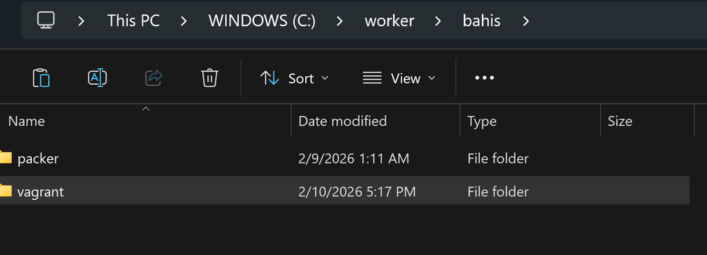

Рисунок 1: Структура рабочего каталога с подкаталогами packer и vagrant

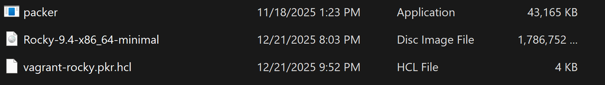

Рисунок 2: Содержимое каталога packer с ISO-образом и HCL-файлом

- Файл `vagrant-rocky.pkr.hcl` содержит блок `packer` и `required_plugins`
- Заданы переменные версии, диска, ISO, архитектуры и SSH
- В каталоге `http` размещён файл `ks.cfg`
- Определены параметры автоматической установки

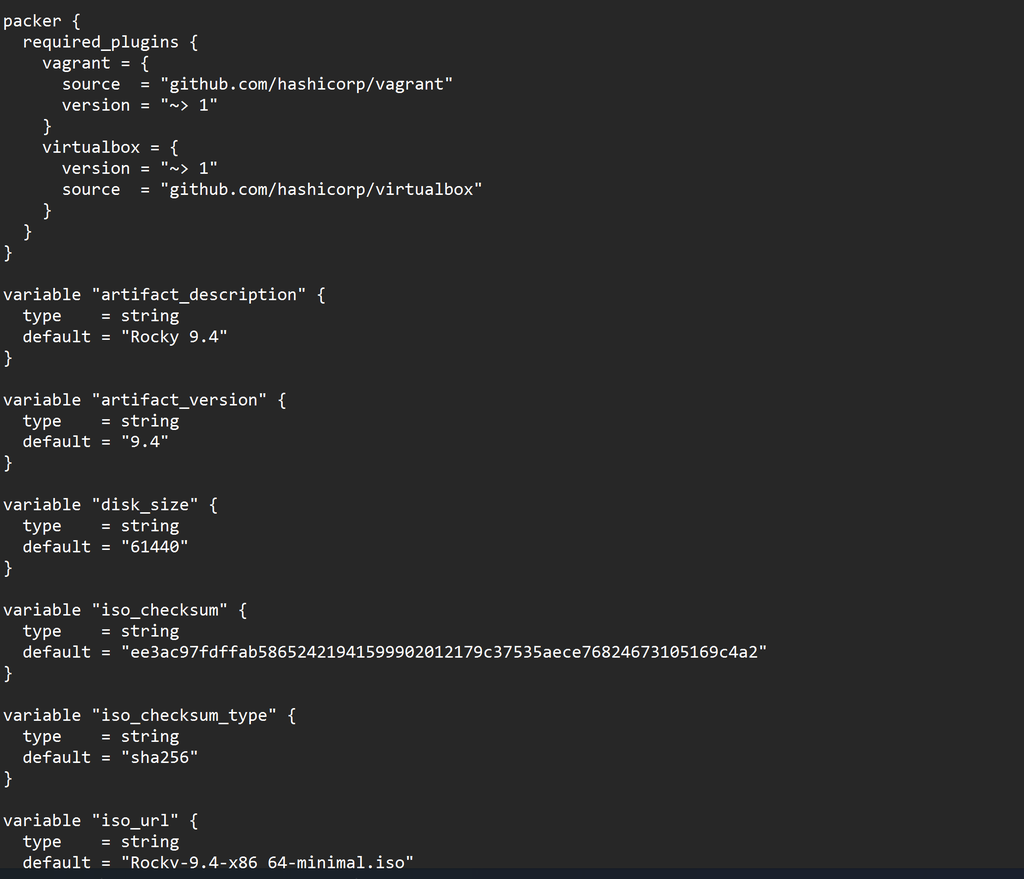

Рисунок 3: Файл vagrant-rocky.pkr.hcl с описанием переменных и плагинов

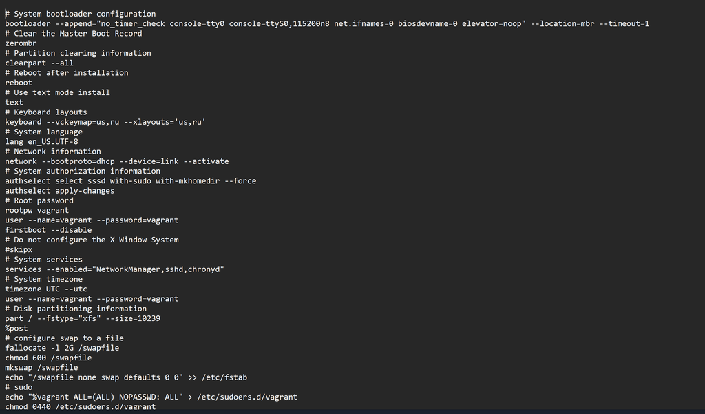

Рисунок 4: Файл ks.cfg с параметрами автоматической установки Rocky Linux

- В каталоге `vagrant` создан файл `Vagrantfile`
- Определена ВМ `server` с box `rocky9`
- Настроены IP 192.168.1.1 и параметры VirtualBox
- Создан каталог `provision` с подкаталогами `default`, `server`, `client`

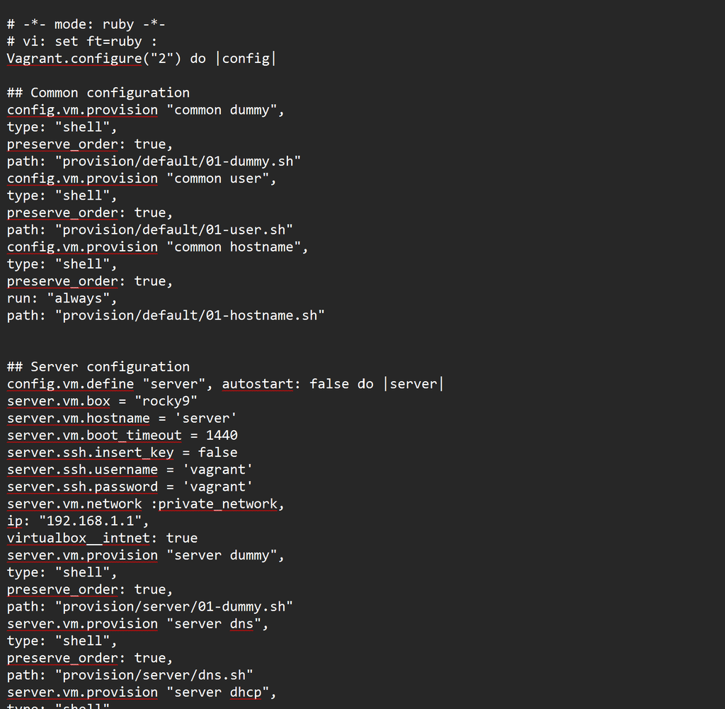

Рисунок 5: Файл Vagrantfile с конфигурацией виртуальной машины server

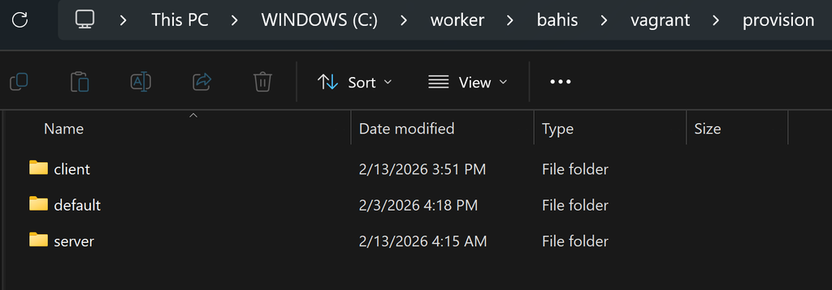

Рисунок 6: Структура каталога provision с подкаталогами default, server и client

- В каталогах размещены скрипты-заглушки `01-dummy.sh`

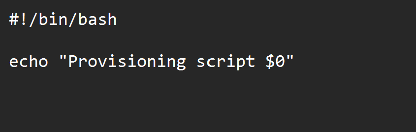

Рисунок 7: Скрипты-заглушки 01-dummy.sh в каталогах default, server и client

- В `default` добавлен `01-user.sh`
- Создание пользователя `bahis`
- Добавление в группу `wheel`
- Настройка PS1

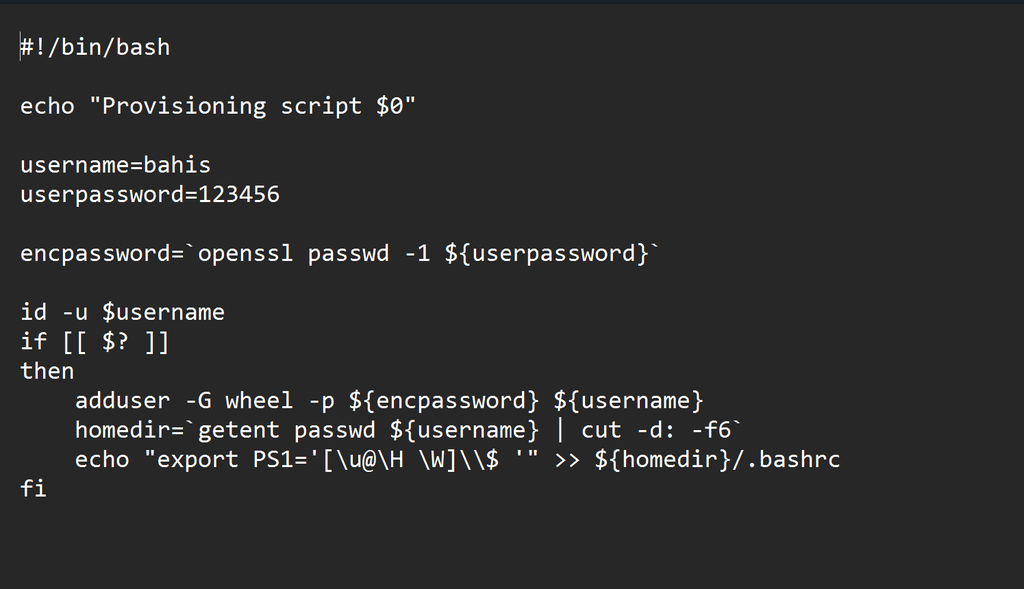

Рисунок 8: Скрипт 01-user.sh для создания пользователя и настройки окружения

- В `default` добавлен `01-hostname.sh`
- Установка FQDN вида `*.bahis.net`

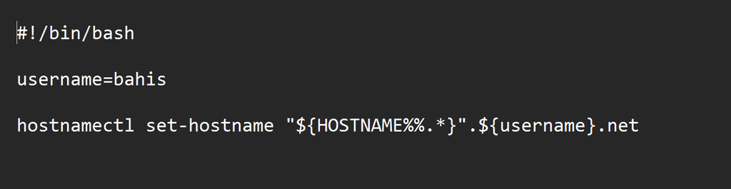

Рисунок 9: Скрипт 01-hostname.sh для установки доменного имени хоста

- В `server` размещён `02-forward.sh`
- Включение IP-forwarding
- Настройка masquerading через firewalld

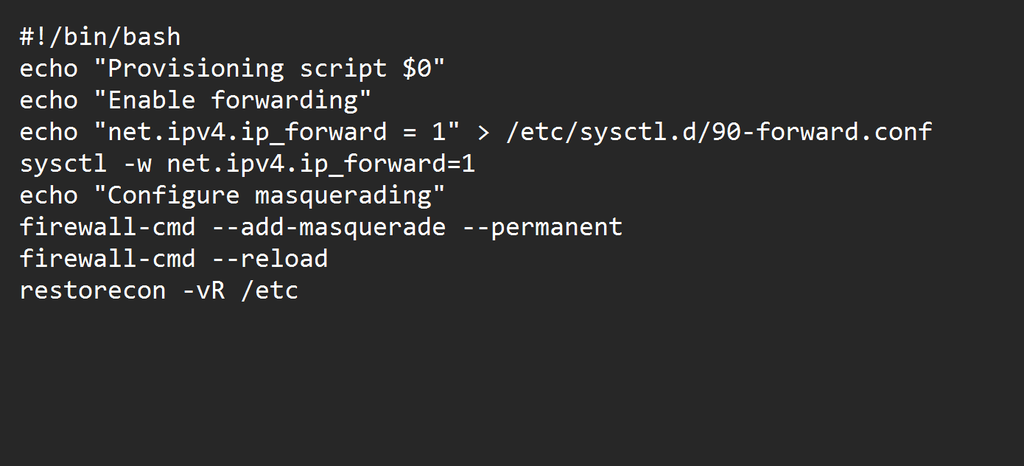

Рисунок 10: Скрипт 02-forward.sh для включения IP-forwarding и masquerading

- В `client` размещён `01-routing.sh`
- Настройка шлюза 192.168.1.1
- Конфигурация интерфейсов через nmcli

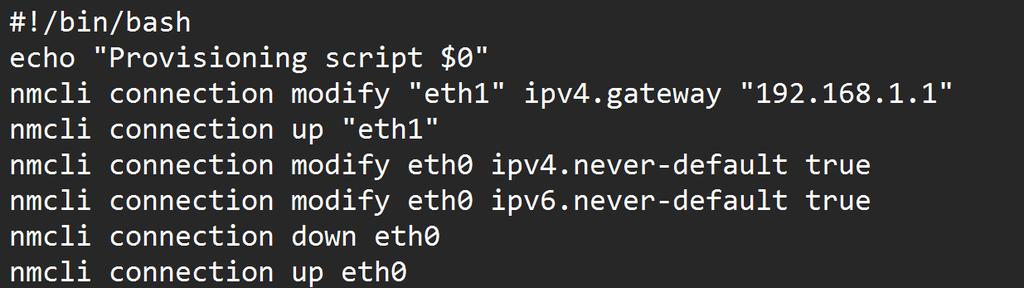

Рисунок 11: Скрипт 01-routing.sh для настройки маршрутизации клиента

## Развёртывание лабораторного стенда на ОС Windows

- Выполнены `packer.exe init` и `packer.exe build`
- Произведена автоматическая установка Rocky Linux
- Сформирован box-файл

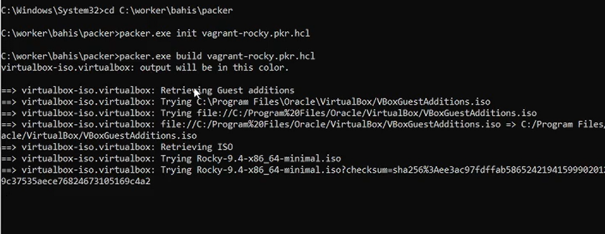

Рисунок 12: Выполнение команд packer.exe init и packer.exe build

- Создан файл `vagrant-virtualbox-rocky-9-x86_64.box`
- Подтверждена корректная сборка образа

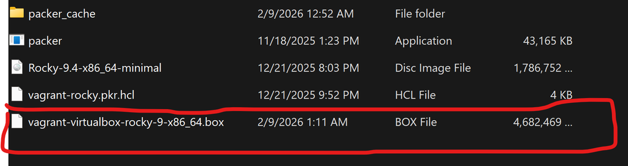

Рисунок 13: Сформированный box-файл vagrant-virtualbox-rocky-9-x86_64.box

- Выполнена регистрация box через `vagrant box add rocky9`
- Образ добавлен под именем `rocky9`

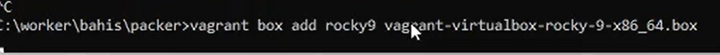

Рисунок 14: Регистрация box-файла в Vagrant

- Запуск `vagrant up server`
- Инициализация сети и provisioning

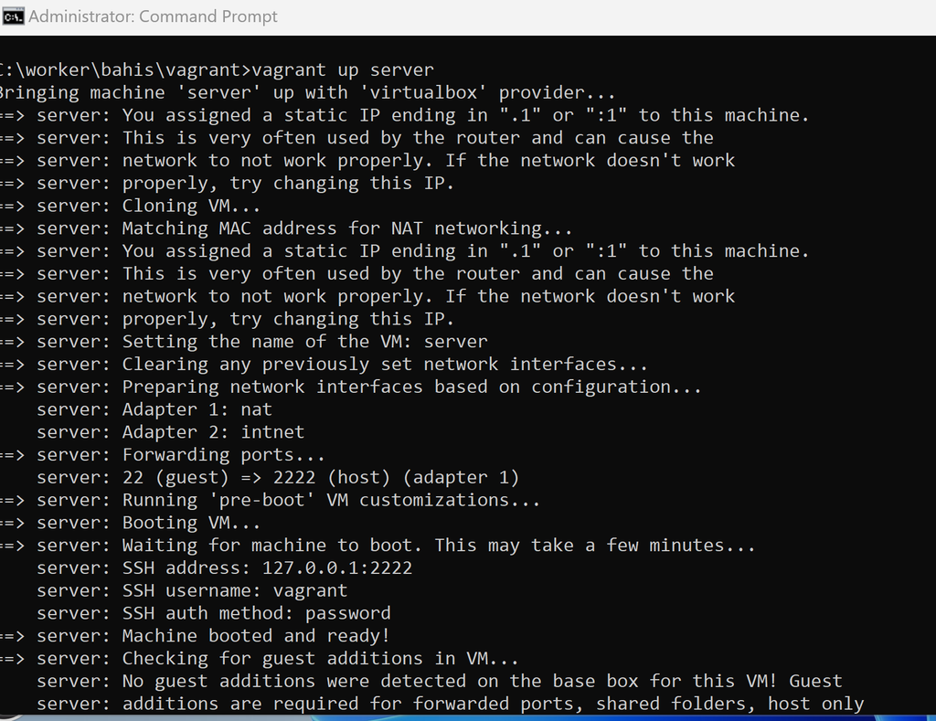

Рисунок 15: Запуск виртуальной машины server через vagrant up

- Запуск `vagrant up client`
- Настройка сетевых адаптеров
- Подключение по SSH

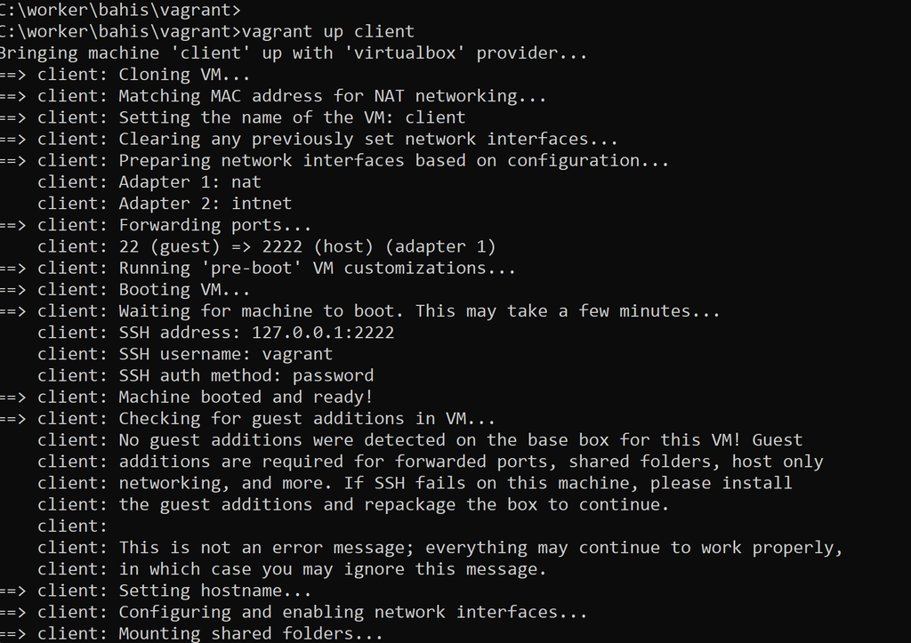

Рисунок 16: Запуск виртуальной машины client через vagrant up

- Обе ВМ успешно загружены в VirtualBox
- Выполнен вход под пользователем `vagrant`

[figure not shown]

Рисунок 17: Графический вход в систему на виртуальной машине server

[figure not shown]

Рисунок 18: Графический вход в систему на виртуальной машине client

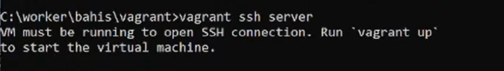

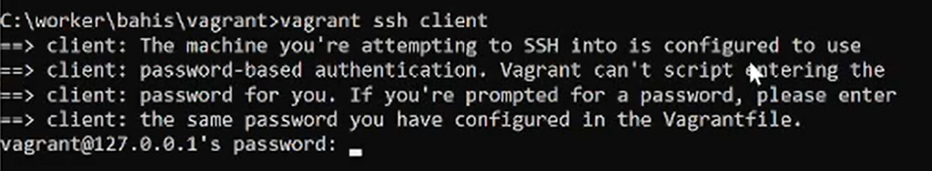

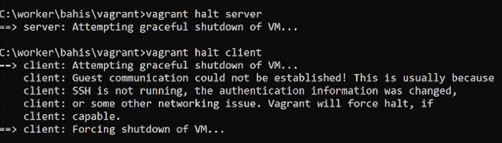

Рисунок 21: Остановка виртуальных машин server и client

## Внесение изменений в настройки внутреннего окружения виртуальной машины

- В `Vagrantfile` добавлены блоки `common user` и `common hostname`
- Обеспечено выполнение `01-user.sh` и `01-hostname.sh`

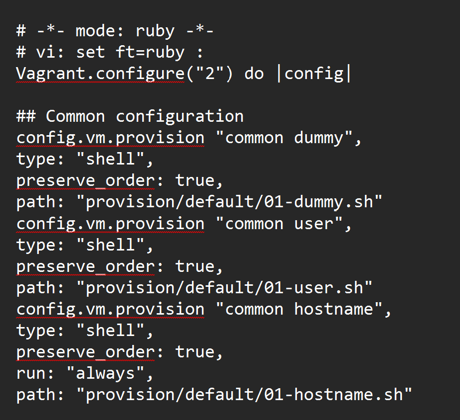

Рисунок 22: Фрагмент Vagrantfile с блоками common user и common hostname

- Выполнены `vagrant up --provision` для server и client
- Повторный запуск provisioning
- Подтверждено существование пользователя `bahis`

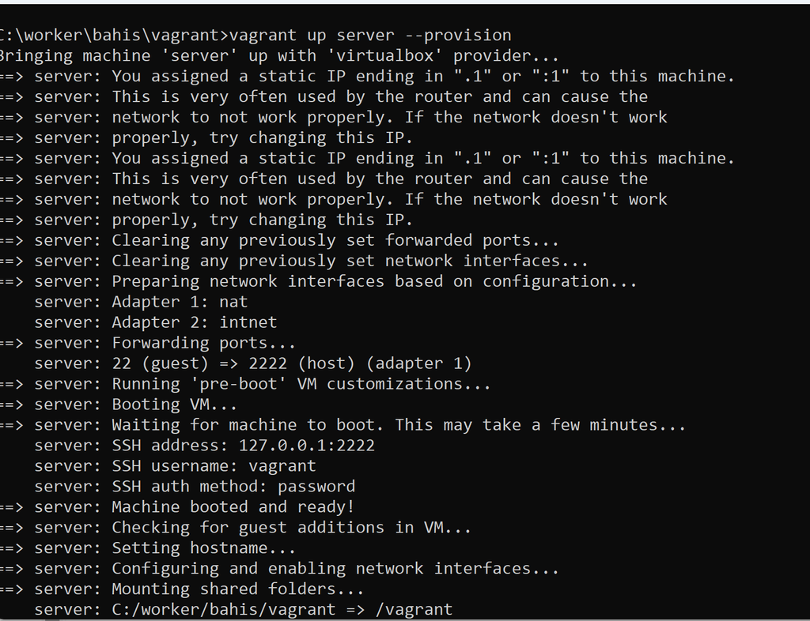

Рисунок 23: Повторный запуск server с ключом –provision

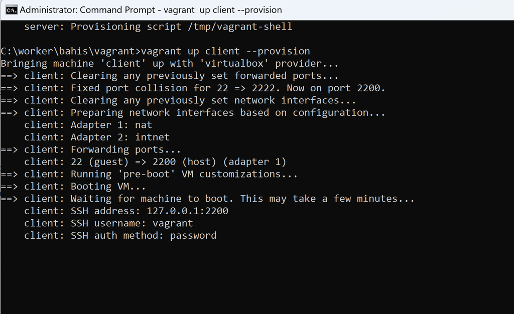

Рисунок 24: Повторный запуск client с ключом –provision

[figure not shown]

Рисунок 25: Графический вход под пользователем bahis на сервере

[figure not shown]

Рисунок 26: Графический вход под пользователем bahis на клиенте

# Выводы